# PG3 - Grupo 9

## Intregrantes:

- Caio Pereira Neris 11202230288
- Mateus Batistelli Vignola 11202230362

# Artigo: Risco cardiometabólico em adolescentes estudantes do ensino médio: influência do trabalho

Artigo Disponível em: https://doi.org/10.1590/0034-7167-2019-0041

Link pro PDF em português: https://www.scielo.br/j/reben/a/7y6fG8JzKdR7BhYngdzmfnG/?lang=pt&format=pdf

Base de dados e Análise original disponíveis em: https://doi.org/10.25824/redu/TDCCSB

**Banco de dados, estruturas e tabelas utilizadas**

Pelo link acima, é possível baixar dois arquivos .xlsx, no primeiro arquivo (nomeado coleta de dados) há todos os dados brutos coletados na pesquisa para todas as inúmeras variáveis utilizadas. Aqui está um print de alguns dos dados disponíveis

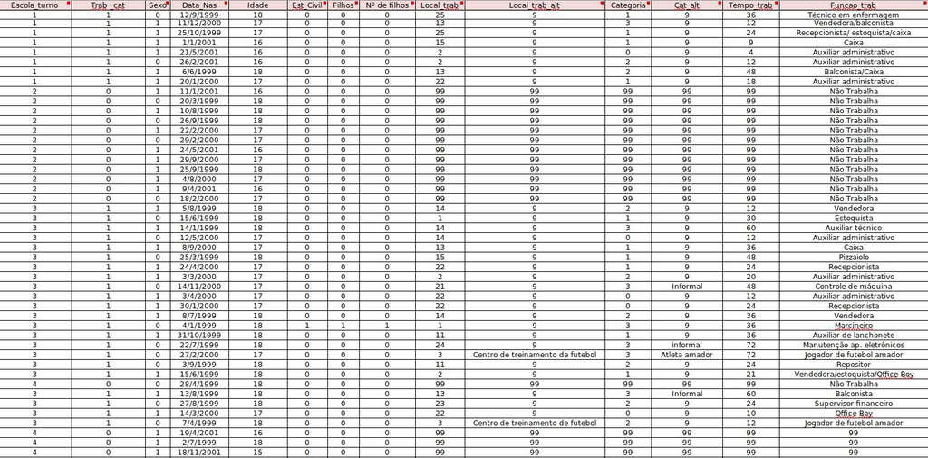

No segundo arquivo, estão resumidas as diversas análises em várias páginas com as estatísticas relevantes, tais como média, desvio padrão e p-valor, sendo indicado também qual teste foi usado. A seguir há um print da visualização dos dados já importados no RStudio.

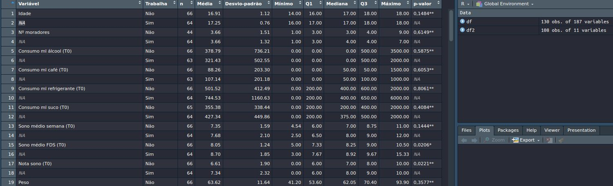

**Resumo do artigo:** O estudo buscou entender e comparar a frequência de fatores de risco para doenças do coração e metabolismo entre adolescentes, e como esses fatores são influenciados pelo trabalho. Como modelo, os pesquisadores coletaram informações sobre a alimentação, atividade física e outras características desses jovens. Descobriram que muitos adolescentes tinham uma dieta inadequada, não praticavam exercícios e alguns apresentavam pressão alta. Além disso, notaram que aqueles que trabalhavam tinham mais tendência a beber álcool, fazer menos atividades físicas e ter um sono de menor qualidade. O estudo concluiu que o trabalho pode aumentar o risco de problemas de saúde para esses jovens.

## Resumo dos experimentos:

Como dito, o estudo avaliou o impacto do trabalho na ocorrência de fatores de risco cardiometabólico em adolescentes.

#### Fatores analisados:

Ao todo foram analisados 53 fatores de risco neste artigo, decidimos então selecionar 4 deles para re-análisar em nosso trabalho. Foram estes a qualidade de **sono**, a prática de **atividade física**, o consumo de **álcool** e o de **tabaco** dos participantes.

## Resumo dos resultados:

Foi encontrado uma queda de 1,4 (notas de zero a dez) na média das notas do sono após os participantes começarem a trabalhar, com um p-valor de 0,0011 e um nível de significância de 0,05 , rejeitando a hipótese nula.

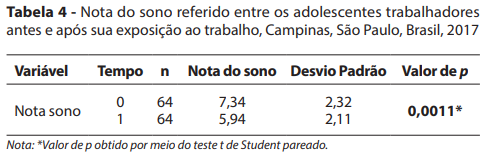

O estudo mostrou que uma parte significativa dos jovens, especialmente do sexo masculino, já trabalha, associado a uma maior renda familiar. Cerca de 7,7% dos participantes tinham pressão arterial elevada, mais comum entre os que trabalham. Não houve relação clara entre trabalho e os valores específicos de pressão arterial. Aproximadamente 28,3% dos adolescentes estavam acima do peso, com percentuais semelhantes entre trabalhadores e não trabalhadores.

Nenhum adolescente teve uma dieta adequada pelo IQD-R, com a maioria precisando de modificações na dieta ou apresentando uma dieta inadequada. O consumo de bebidas açucaradas foi alto em ambos os grupos. O trabalho associou-se ao consumo de álcool, mas não ao tabaco ou à prática de atividade física (somente o teste McNemar indicou associação com a atividade física). A qualidade do sono piorou significativamente após os adolescentes começarem a trabalhar.

Nesta tabela, os p valores foram retirados de uma análise com teste qui-quadrado:

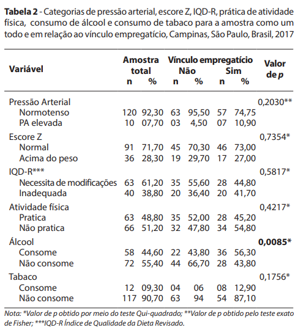

Já aqui foi utilizado o teste de McNemar:

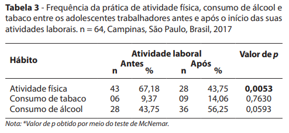

## Resumo das Conclusões:

Em relação aos fatores que selecionamos para avaliar, o estudo verificou que ao começarem a trabalhar os adolescentes relataram uma menor qualidade no sono, um aumento da ingestão de álcool e a redução da prática de atividade física. Já sobre o consumo de tabaco, não houve indícios de correlação com o trabalho.

# Nossa análise:

Aqui está disposta nossa análise estatística com os dados obtidos pelos pesquisadores no que diz respeito às variáveis que citamos: a qualidade de **sono**, a prática de **atividade física**, o consumo de **álcool** e o de **tabaco** dos participantes e suas associações com o trabalho. É importante ressaltar que algumas das nossas análises tem dados diferentes do artigo, mas utilizamos a própria base de dados fornecida por eles e não sabemos de onde vem essas incongruências ou de onde eles tiraram alguns dos dados utilizados, como no caso da análise do álcool, que na base fornecida conta com 23 dos adolescentes que não trabalham consumindo álcool e 43 sem consumir, mas no artigo aparecem como 22 e 44, respectivamente. Em alguns outros casos, como na análise da atividade física, eles utilizaram as informações de 129 dos 130 participantes, mas não especificaram qual deles ficou de fora para que pudéssemos reproduzir. De toda forma, utilizamos os dados da base fornecida para nossa análise.

### Acesso aos dados:

Para começar, separamos os dados que iríamos utilizar do restante da tabela. Salvamos isso em um arquivo de tabelas do google (google sheets) e acessamos o arquivo por um link do google drive com o uso da biblioteca para R “googlesheets4”. Também disponibilizamos esse arquivo, criado por nós, para download pelo link a seguir:

[Baixar nossa tabela de dados](https://github.com/Caio-P-Neris/analise_de_dados_infer.estatistica/raw/main/Dados_IIE.xlsx)

Acessando a base pelo google drive:

```r
library(googlesheets4)
data <- read_sheet("https://docs.google.com/spreadsheets/d/1EAz9VfynYRpjfG6EIKyKPeJICMxELDL0RG_qa37kDpA/edit?gid=0#gid=0")
```

[output not shown]

[output not shown]

[output not shown]

[output not shown]

```
## ✔ Reading from "Dados_IIE".
```

```
## ✔ Range 'Página1'.
```

Aqui colocamos um print da tabela que construímos com os dados da base de dados deles:

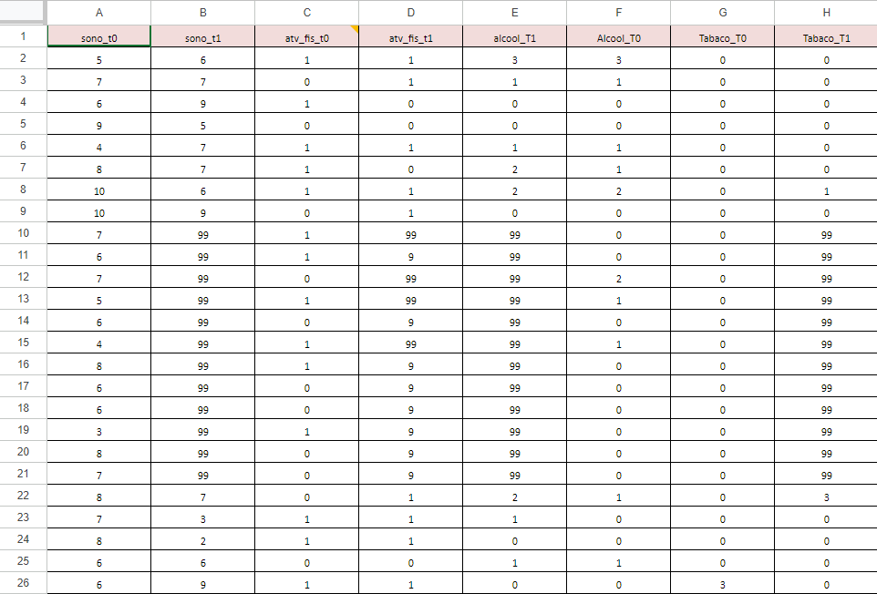

Vale notar que a variável do sono é contínua, pois foi pedido que os participantes atribuíssem notas de 0 a 10 à qualidade do seu sono, já as outras variáveis possuem alguns valores que variam de 1 a 5 em alguns casos, mas segundo o artigo foram tratadas como binárias, de forma que se o participante consumia álcool, tabaco ou praticava atividade física em qualquer quantidade/frequência foi considerado como consumidor/praticante, e só ficou de fora quem não consumia/praticava nada. As colunas são divididas em T0, onde estão armazenadas as informações dos estudantes que não trabalham e as informações de como era antes do trabalho para aqueles que já tem vínculo empregatício; e T1, onde estão armazenadas as informaões atuais dos estudantes que trabalham. Outro detalhe importante é o fato de que eles utilizaram o número 99 como um marcador nas colunas com os dados dos tabalhadores para participantes que não trabalhavam (sono_t1, atv_fis_t1, alcool_T1 e Tabaco_T1) e houve um erro na coluna atv_fis_t1, que é binária, onde alguns marcadores ficaram somente com um 9 ao invés de 99, mas é possível ver que eles encaixam perfeitamente nos 99 da coluna alcool_T1 ao lado. Com isso dito, podemos seguir para nossas análises desses dados, começando com a do sono.

### Análise do sono:

```r
media_sono_n = mean(data$sono_t0[data$sono_t1 != 99])

media_sono_trabalha <- mean(data$sono_t1[data$sono_t1 != 99])

shapiro.test(data$sono_t0[data$sono_t1 != 99])
```

```
##
##  Shapiro-Wilk normality test
##
## data:  data$sono_t0[data$sono_t1 != 99]
## W = 0.90627, p-value = 0.0001391
```

```r
shapiro.test(data$sono_t1[data$sono_t1 != 99])
```

```
##
##  Shapiro-Wilk normality test
##
## data:  data$sono_t1[data$sono_t1 != 99]
## W = 0.96942, p-value = 0.1128
```

```r
t.test(data$sono_t1[data$sono_t1 != 99], data$sono_t0[data$sono_t1 != 99], alternative = 'two.sided', mu = 0, paired = TRUE)
```

```
##
##  Paired t-test
##
## data:  data$sono_t1[data$sono_t1 != 99] and data$sono_t0[data$sono_t1 != 99]
## t = -3.4107, df = 63, p-value = 0.001136
## alternative hypothesis: true mean difference is not equal to 0
## 95 percent confidence interval:
##  -2.2301854 -0.5823146
## sample estimates:
## mean difference
##        -1.40625
```

Os dados das notas de sono de quem não trabalha não passaram no teste que averigua normalidade, sem essa premissa, não é possível fazer o teste t pareado para obter o p-valor. Podemos calcular o p-valor corretamente por boostrap:

```r
medidas_sono = c(data$sono_t0[data$sono_t1 != 99], data$sono_t1[data$sono_t1 != 99])
grupos_sono <- c(rep(1, length(data$sono_t0[data$sono_t1 != 99])), rep(2, length(data$sono_t1[data$sono_t1 != 99])))

delta_sono = media_sono_n - media_sono_trabalha

delta_sono_perm = vector()
for (p in 1:10000){
    grupos_sono_perm = sample(grupos_sono, length(grupos_sono), replace = 'FALSE')
    delta_sono_perm[p] = mean(medidas_sono[grupos_sono_perm == 1]) - mean(medidas_sono[grupos_sono_perm == 2])
}

p_valor_sono = 2*mean(delta_sono_perm > delta_sono)
p_valor_sono
```

```
## [1] 2e-04
```

Obtemos, então, um p valor de praticamente zero com o procedimento booststrap, chegando a mesma conclusão do artigo, de rejeição da hipótese nula (de que a média da qualidade de sono seria a mesma antes e depois dos participantes começarem a trabalhar).

Resultado do artigo para comparação:

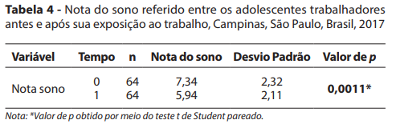

### Análise da atividade física:

Para avaliar a relação entre o trabalho e a prática de atividade física, foram utilizados dois testes. O teste qui-quadrado, que investigou a associação entre os fatores trabalho e prática de exercícios em amostras independentes, e o teste McNemar que avaliou essa associação em amostras pareadas.

**Teste qui-quadrado:**

Para não nos preocuparmos com as premissas do teste qui quadrado, que são um pouco complicadas, optamos por um teste não paramétrico:

```r
rm(list = ls()) #limpando as variáveis e recuperando os dados
data <- read_sheet("https://docs.google.com/spreadsheets/d/1EAz9VfynYRpjfG6EIKyKPeJICMxELDL0RG_qa37kDpA/edit?gid=0#gid=0")
```

```
## ✔ Reading from "Dados_IIE".
```

```
## ✔ Range 'Página1'.
```

```r
#Transformamos a lista de quem trabalha em um vetor de true e false, para prática de exercício
atv_fis_trabalham = data$atv_fis_t1[(data$atv_fis_t1 == 0) | (data$atv_fis_t1 == 1)] != 0

#Fizemos a mesma coisa com quem não trabalha
atv_fis_NAOtrabalham = data$atv_fis_t0[(data$atv_fis_t1 == 99) | (data$atv_fis_t1 == 9)] != 0

#Contabilizamos a quantidade em cada grupo, baseado no número de true e de false
exercitam_trabalham = sum(atv_fis_trabalham == TRUE)
NAOexercitam_trabalham = sum(atv_fis_trabalham == FALSE)
exercitam_NAOtrabalham = sum(atv_fis_NAOtrabalham == TRUE)
NAOexercitam_NAOtrabalham = sum(atv_fis_NAOtrabalham == FALSE)

# Criando a tabela manualmente
tabela_atv_fis <- matrix(c(exercitam_NAOtrabalham , exercitam_trabalham, NAOexercitam_NAOtrabalham, NAOexercitam_trabalham ),
                        nrow = 2, byrow = TRUE)

# Nomeando as dimensões da tabela
dimnames(tabela_atv_fis) <- list(Exercício = c('Pratica', 'Não pratica'),
                                Trabalho = c('Não trabalha', 'Trabalha'))

tabela_atv_fis
```

```
##              Trabalho
## Exercício    Não trabalha Trabalha
##   Pratica               35       28
##   Não pratica           31       36
```

```r
#Salvamos os dados do qui-quadrado numa variável temporária
temp = chisq.test(tabela_atv_fis,correct=FALSE)

#Aqui salvamos o valor do qui-qauadrado observado
x2_obs = temp$statistic

#Seguimos pro teste não paramétrico:
x2_acaso = rep(NA,10000)

n = sum(temp$observed)

limites = c( cumsum( temp[["expected"]] / n ) )

for (b in 1:10000){
    amostra_bs_esp = rep(1,n)
    aleatoriza = runif(n)
    for (l in 2:length(limites)){
        index = aleatoriza > limites[l-1] & aleatoriza <= limites[l]
        amostra_bs_esp[index] = l
    }

    tabela_esperado = rbind( c( sum(amostra_bs_esp == 1) , sum(amostra_bs_esp == 2) ) , c( sum(amostra_bs_esp == 3) , sum(amostra_bs_esp == 4) ) )

    temp2 = chisq.test(tabela_esperado,correct=FALSE)
    x2_acaso[b] = temp2$statistic
}

pvalor = mean( x2_acaso >= x2_obs)
pvalor
```

```
## [1] 0.291
```

Obtivemos um p-valor de quase 0.29 ou 29%, o que nos leva a aceitar a hipótese nula de que esses fatores seriam independentes, ou seja, não há evidências suficientes para afirmar que existe uma associação entre o trabalho e a prática de exercício físico na adolescência na adolescência, para grupos não pareados.

Resultado do artigo para comparação:

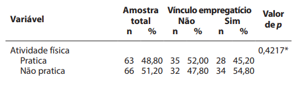

**Teste McNemar:**

O teste McNemar avalia a associação entre fatores para amostras pareadas. Utilizou-se ele para avaliar a associação entre o exercício físico e o trabalho com os dados da prática por adolescêntes antes e depois de começarem a trabalhar.

```r
#criamos um vetor de True e False para a prática de exercício dos participantes, antes de trabalharem (T0) e depois de começarem a trabalhar (T1):
t0_atv_fis = data$atv_fis_t0[data$atv_fis_t1 != 99 & data$atv_fis_t1 != 9] > 0
t1_atv_fis = data$atv_fis_t1[data$atv_fis_t1 != 99 & data$atv_fis_t1 != 9] > 0

#dividimos então em grupos, aqueles que não bebiam antes e se mantiveram sem beber, os que não bebiam e começaram a beber, os que bebiam e pararam e, por fim, os que já bebiam e continuaram
nao0_nao1 = sum(t0_atv_fis == FALSE & t1_atv_fis == FALSE)
nao0_sim1 = sum(t0_atv_fis == FALSE & t1_atv_fis == TRUE)
sim0_nao1 = sum(t0_atv_fis == TRUE & t1_atv_fis == FALSE)
sim0_sim1 = sum(t0_atv_fis == TRUE & t1_atv_fis == TRUE)

tabela_t0vst1 = rbind( c( nao0_nao1 , nao0_sim1 ) , c( sim0_nao1 , sim0_sim1) )
dimnames(tabela_t0vst1) = list( Atv_Fis_T0 = c('Não praticava','Praticava') , Atv_Fis_T1 = c('Não pratica','pratica') )

tabela_t0vst1
```

```
##                Atv_Fis_T1
## Atv_Fis_T0      Não pratica pratica
##   Não praticava          14       7
##   Praticava              22      21
```

```r
mcnemar.test(tabela_t0vst1,correct = FALSE)
```

```
##
##  McNemar's Chi-squared test
##
## data:  tabela_t0vst1
## McNemar's chi-squared = 7.7586, df = 1, p-value = 0.005346
```

Obtivemos um p-valor de 0.0053 ou 0,53%, levando a rejeição da hipótese nula. No caso do teste McNemar, a hipótese nula é a de que a probabilidade de um indivíduo que não praticava exercícios começar a praticar (depois do trabalho) é mesma probabilidade de um indivíduo que praticava, parar com a atividade, ou seja, que o trabalho não exerce influência na prática de atividade física. Rejeitada essa hipótese, sabemos que existem evidências o suficiente para afirmar que o trabalho exerce influência na prática de atividade física pelos adolescentes. Para amostras não pareadas obtivemos o resultado oposto, de que não existe associação entre eles.

Resultado do artigo para comparação:

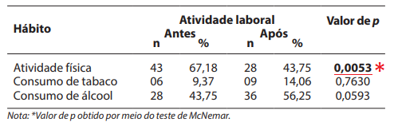

### Análise do consumo de álcool:

Para avaliar a relação entre o trabalho e o consumo de álcool, foram utilizados os mesmos testes. O teste qui-quadrado, que investigou a associação entre os fatores trabalho e consumo de bebida em amostras independentes, e o teste McNemar que avaliou essa associação em amostras pareadas.

**Teste qui-quadrado:**

De novo optamos por um teste qui quadrado não paramétrico:

```r
rm(list=ls())
library(googlesheets4)
data <- read_sheet("https://docs.google.com/spreadsheets/d/1EAz9VfynYRpjfG6EIKyKPeJICMxELDL0RG_qa37kDpA/edit?gid=0#gid=0")
```

```
## ✔ Reading from "Dados_IIE".
```

```
## ✔ Range 'Página1'.
```

```r
#Transformamos a lista de quem trabalha em um vetor de true e false, pra consumo de alcool
alcool_trabalham = data$alcool_T1[data$alcool_T1 != 99] != 0

#Fizemos a mesma coisa com quem não trabalha
alcool_NAOtrabalham = data$Alcool_T0[data$alcool_T1 == 99] != 0

#Contabilizamos a quantidade em cada grupo, baseado no número de true e de false
bebem_trabalham = sum(alcool_trabalham == TRUE)
NAObebem_trabalham = sum(alcool_trabalham == FALSE)
bebem_NAOtrabalham = sum(alcool_NAOtrabalham == TRUE)
NAObebem_NAOtrabalham = sum(alcool_NAOtrabalham == FALSE)

# Criando a tabela manualmente
tabela_alcool <- matrix(c(bebem_NAOtrabalham , bebem_trabalham, NAObebem_NAOtrabalham, NAObebem_trabalham ),
                        nrow = 2, byrow = TRUE)

# Nomeando as dimensões da tabela
dimnames(tabela_alcool) <- list(Alcool = c('Bebe', 'Não bebe'),
                                Trabalho = c('Não trabalha', 'Trabalha'))

tabela_alcool
```

```
##           Trabalho
## Alcool     Não trabalha Trabalha
##   Bebe               23       36
##   Não bebe           43       28
```

```r
#Salvamos os dados do qui-quadrado numa variável temporária
temp = chisq.test(tabela_alcool,correct=FALSE)

#Aqui salvamos o valor do qui-qauadrado observado
x2_obs_alcool = temp$statistic

#Seguimos pro teste não paramétrico:
x2_acaso_alcool = rep(NA,10000)

n_alcool = sum(temp$observed)

limites_alcool = c( cumsum( temp[["expected"]] / n_alcool ) )

for (b in 1:10000){
    amostra_bs_esp = rep(1,n_alcool)
    aleatoriza = runif(n_alcool)
    for (l in 2:length(limites_alcool)){
        index = aleatoriza > limites_alcool[l-1] & aleatoriza <= limites_alcool[l]
        amostra_bs_esp[index] = l
    }

    tabela_esperado = rbind( c( sum(amostra_bs_esp == 1) , sum(amostra_bs_esp == 2) ) , c( sum(amostra_bs_esp == 3) , sum(amostra_bs_esp == 4) ) )

    temp2 = chisq.test(tabela_esperado,correct=FALSE)
    x2_acaso_alcool[b] = temp2$statistic
}

pvalor_alcool = mean( x2_acaso_alcool >= x2_obs_alcool)
pvalor_alcool
```

```
## [1] 0.0139
```

Obtivemos um p-valor próximo de 0.015 ou 1,5%, o que nos leva a rejeitar a hipótese nula de que esses fatores seriam independentes, ou seja, parece haver evidências suficientes para afirmar que existe uma associação entre o trabalho e consumo de bebida alcoólica na adolescência.

Resultado do artigo para comparação:

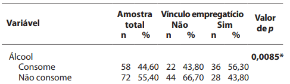

**Teste McNemar:**

Utilizou-se o teste McNemar para avaliar a associação entre álcool e trabalho com os dados de consumo dos adolescentes antes e depois de começarem a trabalhar.

```r
#criamos um vetor de True e False para o consumo de álcool dos participantes, antes de trabalharem (T0) e depois de começarem a trabalhar (T1):
t0_alcool = data$Alcool_T0[data$alcool_T1 != 99] > 0
t1_alcool = data$alcool_T1[data$alcool_T1 != 99] > 0

#dividimos então em grupos, aqueles que não bebiam antes e se mantiveram sem beber, os que não bebiam e começaram a beber, os que bebiam e pararam e, por fim, os que já bebiam e continuaram
nao0_nao1 = sum(t0_alcool == FALSE & t1_alcool == FALSE)
nao0_sim1 = sum(t0_alcool == FALSE & t1_alcool == TRUE)
sim0_nao1 = sum(t0_alcool == TRUE & t1_alcool == FALSE)
sim0_sim1 = sum(t0_alcool == TRUE & t1_alcool == TRUE)

tabela_t0vst1 = rbind( c( nao0_nao1 , nao0_sim1 ) , c( sim0_nao1 , sim0_sim1) )
dimnames(tabela_t0vst1) = list( Álcool_T0 = c('Não bebia','Bebia') , Álcool_T1 = c('Não bebe','Bebe') )

tabela_t0vst1
```

```
##            Álcool_T1
## Álcool_T0  Não bebe Bebe
##   Não bebia       23   13
##   Bebia            5   23
```

```r
mcnemar.test(tabela_t0vst1,correct = FALSE)
```

```
##
##  McNemar's Chi-squared test
##
## data:  tabela_t0vst1
## McNemar's chi-squared = 3.5556, df = 1, p-value = 0.05935
```

Obtivemos, pela função nativa, um p-valor de 0.05935 ou 5,935%, acima do nível de significância, nos levando a aceitar a hipótese nula, de que o consumo de bebida não é afetado pelo trabalho. É estranho, pois novamente chegamos a uma conclusão diferente da que obtivemos com amostras não pareadas.

Resultado do artigo para comparação:

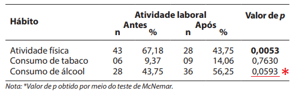

### Análise do consumo de tabaco:

Novamente foram utilizados o qui quadrado e o McNemar para avaliar a relação entre o trabalho e o consumo de tabaco. O teste qui-quadrado com amostras independentes, e o McNemar, amostras pareadas.

**Teste qui-quadrado:**

Ainda com o teste qui quadrado não paramétrico:

```r
rm(list=ls())

library(googlesheets4)
data <- read_sheet("https://docs.google.com/spreadsheets/d/1EAz9VfynYRpjfG6EIKyKPeJICMxELDL0RG_qa37kDpA/edit?gid=0#gid=0")
```

```
## ✔ Reading from "Dados_IIE".
```

```
## ✔ Range 'Página1'.
```

```r
#pegando a lista de quem trabalha e transformando num vetor de true e false, pra consumo de tabaco
tabaco_trabalham = data$Tabaco_T1[data$Tabaco_T1 != 99] > 0

#mesma coisa com quem não trabalha (peguei das posições que tinham 99 na outra coluna)
tabaco_NAOtrabalham = data$Tabaco_T0[data$Tabaco_T1 == 99] > 0

#pegando a quantidade de cada grupo, baseado no número de true e de false
fumam_trabalham = sum(tabaco_trabalham == TRUE)
NAOfumam_trabalham = sum(tabaco_trabalham == FALSE)
fumam_NAOtrabalham = sum(tabaco_NAOtrabalham == TRUE)
NAOfumam_NAOtrabalham = sum(tabaco_NAOtrabalham == FALSE)

# Criando a tabela manualmente
tabela_tabaco <- matrix(c(fumam_NAOtrabalham , fumam_trabalham, NAOfumam_NAOtrabalham, NAOfumam_trabalham ),
                        nrow = 2, byrow = TRUE)

# Nomeando as dimensões da tabela
dimnames(tabela_tabaco) <- list(Tabaco = c('Fuma', 'Não fuma'),
                                Trabalho = c('Não trabalha', 'Trabalha'))

tabela_tabaco
```

```
##           Trabalho
## Tabaco     Não trabalha Trabalha
##   Fuma                4        8
##   Não fuma           62       56
```

```r
#Salvamos os dados do qui-quadrado numa variável temporária
temp = chisq.test(tabela_tabaco,correct=FALSE)

#Aqui salvamos o valor do qui-qauadrado observado
x2_obs_tabaco = temp$statistic

#Seguimos pro teste não paramétrico:
x2_acaso_tabaco = rep(NA,10000)

n_tabaco = sum(temp$observed)

limites_tabaco = c( cumsum( temp[["expected"]] / n_tabaco ) )

for (b in 1:10000){
    amostra_bs_esp = rep(1,n_tabaco)
    aleatoriza = runif(n_tabaco)
    for (l in 2:length(limites_tabaco)){
        index = aleatoriza > limites_tabaco[l-1] & aleatoriza <= limites_tabaco[l]
        amostra_bs_esp[index] = l
    }

    tabela_esperado = rbind( c( sum(amostra_bs_esp == 1) , sum(amostra_bs_esp == 2) ) , c( sum(amostra_bs_esp == 3) , sum(amostra_bs_esp == 4) ) )
    suppressWarnings({
    temp2 = chisq.test(tabela_esperado,correct=FALSE)
    })

    x2_acaso_tabaco[b] = temp2$statistic
}

pvalor_tabaco = mean( x2_acaso_tabaco >= x2_obs_tabaco)
pvalor_tabaco
```

```
## [1] 0.2054
```

O p-valor calculado para o tabaco foi próximo de 0.21 ou 21%, ou seja, acima do nível de significância de 5%, nos levando a aceitar a hipótese nula, de que não existe associação entre o consumo de tabaco e o trabalho na adolescência.

Resultado do artigo para comparação:

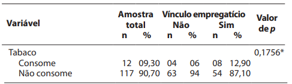

**Teste McNemar:**

Utilizou-se o teste McNemar para avaliar a associação entre o trabalho e o tabaco com os dados de consumo de tabaco antes e depois de começarem a trabalhar.

```r
#criamos um vetor de True e False para o consumo de álcool dos participantes, antes de trabalharem (T0) e depois de começarem a trabalhar (T1):
t0_tabaco = data$Tabaco_T0[data$Tabaco_T1 != 99] > 0
t1_tabaco = data$Tabaco_T1[data$Tabaco_T1 != 99] > 0


# Aqui eu transformei os vetores de true e false em um e zero e rodei o shapiro (tive que por do 1 ao 64 pq quando eu transformei em zero e um ele criou uma espécie de legenda no final do vetor que fala que 1 é TRUE)

#t0_alcool['TRUE'] <- 1
#t1_alcool['TRUE'] <- 1

#shapiro.test(t0_alcool[1:64])

#dividimos então em grupos, aqueles que não bebiam antes e se mantiveram sem beber, os que não bebiam e começaram a beber, os que bebiam e pararam e, por fim, os que já bebiam e continuaram
nao0_nao1 = sum(t0_tabaco == FALSE & t1_tabaco == FALSE)
nao0_sim1 = sum(t0_tabaco == FALSE & t1_tabaco == TRUE)
sim0_nao1 = sum(t0_tabaco == TRUE & t1_tabaco == FALSE)
sim0_sim1 = sum(t0_tabaco == TRUE & t1_tabaco == TRUE)

tabela_t0vst1 = rbind( c( nao0_nao1 , nao0_sim1 ) , c( sim0_nao1 , sim0_sim1) )
dimnames(tabela_t0vst1) = list( Tabaco_T0 = c('Não fumava','Fumava') , Tabaco_T1 = c('Não fuma','Fuma') )

tabela_t0vst1
```

```
##             Tabaco_T1
## Tabaco_T0    Não fuma Fuma
##   Não fumava       50    5
##   Fumava            6    3
```

```r
mcnemar.test(tabela_t0vst1,correct = FALSE)
```

```
##
##  McNemar's Chi-squared test
##
## data:  tabela_t0vst1
## McNemar's chi-squared = 0.090909, df = 1, p-value = 0.763
```

Resultado do artigo para comparação:

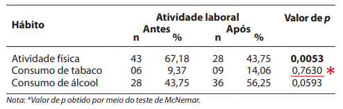

# Conclusão:

Em nossa análise, chegamos às mesmas conclusões que o artigo em todos os testes, ainda que os p valores tenham variado um pouco nos testes qui quadrado (já nos testes McNemar obtivemos exatamente os mesmos resultados). Ficamos um pouco confusos com os resultados da análise da atividade física e do álcool, visto que em ambos chegamos a conclusões diferentes no teste qui quadrado e no McNemar. Como eles trabalham com comparações diferentes, onde o qui quadrado compara amostras independentes (de pessoas que trabalham e pessoas que não) e o McNemar amostras pareadas (com os dados dos adolescentes antes e depois de começarem a trabalhar), pode haver algum aspecto da teoria que explicaria esses diferentes resultados, ou ainda alguma fonte de erro/variabilidade que não foi alcançada por esses testes.